# R Notebook

First we simulate data according to MAMBA.

```r
# fitting simulated MAMBA data to model
if (file.exists("../data/mamba_data.rda") &&
    file.exists("../data/sim_mamba_mod.rda") ) {

  load(file = "../data/mamba_data.rda")
  load(file = "../data/sim_mamba_mod.rda")

  snpeffect <- mamba_data$betajk
  snpvar <- mamba_data$sjk2

} else {
  # simulate data with MAMBA
  mamba_data <- generate_data_mamba()
  save(mamba_data, file = "../data/mamba_data.rda")

  # save effects and variance
  snpeffect <- mamba_data$betajk
  snpvar <- mamba_data$sjk2

  # fit mamba model
  sim_mod <- mamba(betajk = snpeffect, sjk2 = snpvar)
  save(sim_mod, file = "../data/sim_mamba_mod.rda")

}

# take values from model
pprs <- sim_mod$ppr
effectsize <- sim_mod$mu.hat
outlier_prob <- sim_mod$outliermat

# take values from generated data
realeffect <- mamba_data$Rj
trueeffectsize <- mamba_data$muj
```

Next, we ran the posterior_prp function on all SNPs. Below is an example of the code used on the first ten SNPs.

```r
# showing only first ten rows
# first ten rows of data
snpeffect1 <- snpeffect[1:10, ]
snpvar1 <-snpvar[1:10, ]


# convert matrix to list of doubles, each element is a row in the dataset
test_vec_eff = lapply(seq_len(nrow(snpeffect1)),
                      function(x) {
                        snpeffect1[x,]
                      })
test_vec_se = lapply(seq_len(nrow(snpvar1)),
                     function(x) {
                       sqrt(snpvar1[x,])
                     })

list1 = t(mapply(posterior_prp,
                 beta = test_vec_eff,
                 se = test_vec_se))
```

We take the indices for the SNPs that have at least one outlier study.

```r
# indices for snps w/ and w/o outliers
out_studies <- mamba_data$Ojk
out_rows_ind <- which(rowSums(out_studies == 0) > 0) # indices of snps with outlier studies
no_out_rows_ind <-which(rowSums(out_studies) == 10) # indices of rows w/o outliers
```

Then we load in the data containing the PRPs (from PRP package) for each SNP.

```r
# loading data from r scripts
#load(file = "../data/post_prp_data.rda") # post_prp_data
load(file = "../data/post_prp_data_pval.rda") # post_prp_data_pval
#post_prp_data_ch <- read.csv(file = "../data/post_prp_data.csv") # post_prp_data_ch
```

Below are the PPRs and PRPs from the the SNPs with and without outlier studies.

```r
# pprs for snps w/ and w/o outliers
out_ppr <- pprs[out_rows_ind]
nonout_ppr <- pprs[no_out_rows_ind]
```

```r
# prps for snps w/ and w/o outliers
out_prp <- post_prp_data_pval[out_rows_ind]
nonout_prp <- post_prp_data_pval[no_out_rows_ind]
```

For our outlier SNPs, the distribution of our PPRs looks as follows:

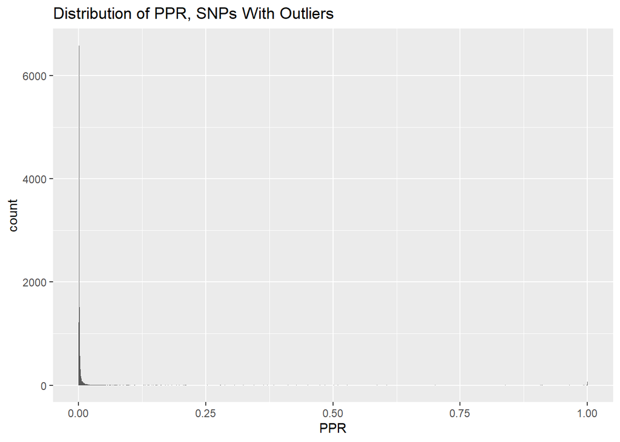

```r
ggplot(data = as.data.frame(out_ppr), aes(out_ppr)) +
  geom_histogram(binwidth = 0.001) +
  ggtitle("Distribution of PPR, SNPs With Outliers") +
  xlab("PPR")
```

Rescaling the graph by ignoring some outliers, we get the histogram below.

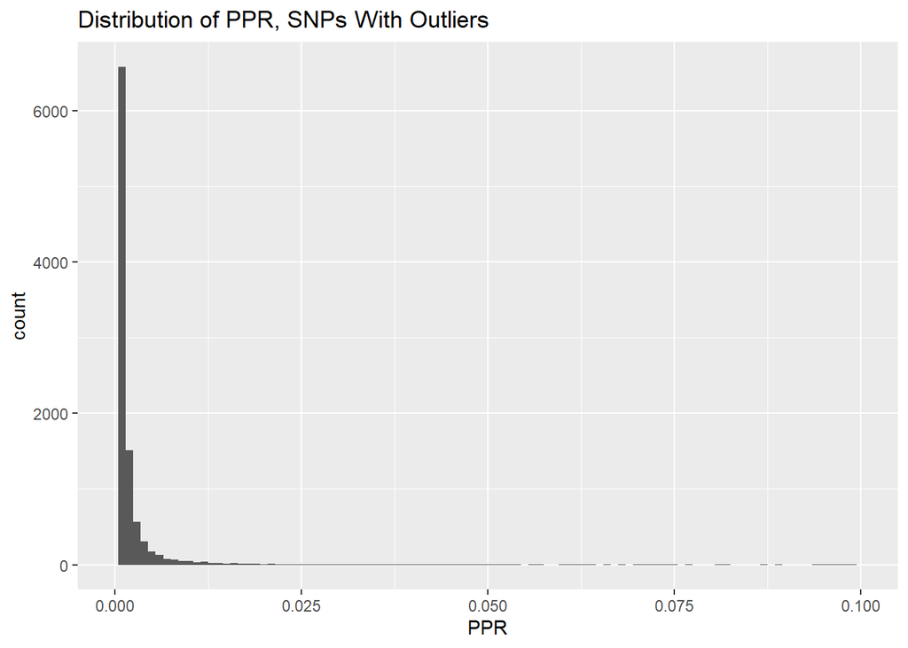

```r
ggplot(data = as.data.frame(out_ppr), aes(out_ppr)) +
  geom_histogram(binwidth = 0.001) +
  ggtitle("Distribution of PPR, SNPs With Outliers") +
  xlab("PPR") +
  xlim(0, 0.1)
```

In contrast, this is what the distribution of our PRPs for outlier SNPs looks like. Keep in mind the differently scaled x-axis.

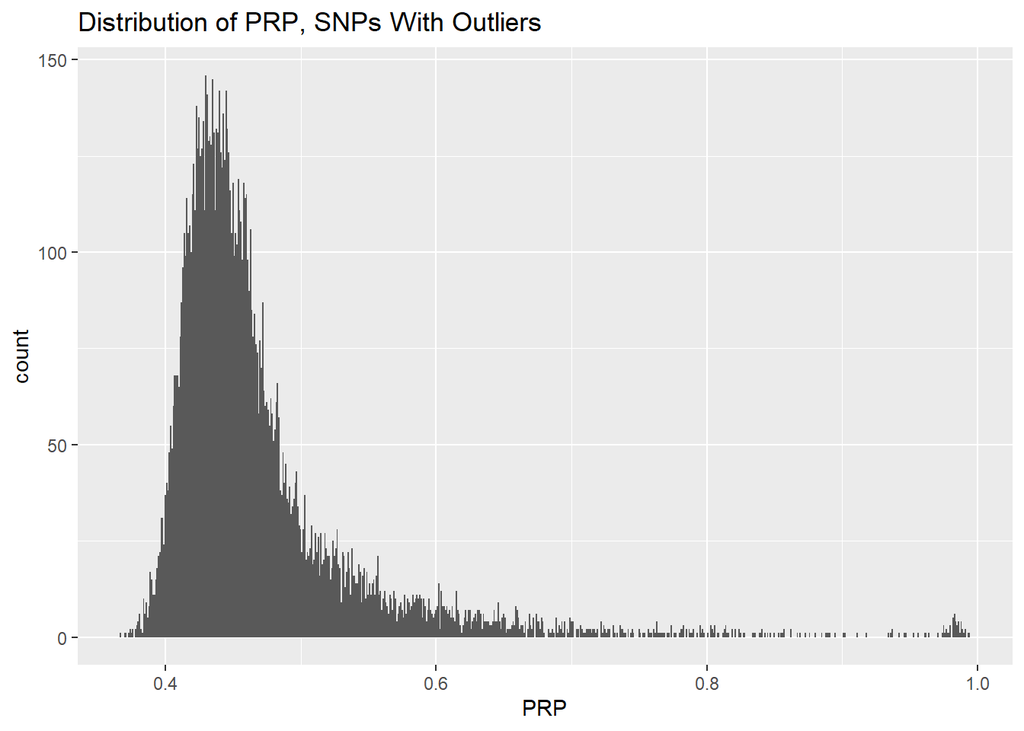

```r
ggplot(data = as.data.frame(out_prp), aes(out_prp)) +
  geom_histogram(binwidth = 0.001) +
  ggtitle("Distribution of PRP, SNPs With Outliers") +
  xlab("PRP")
```

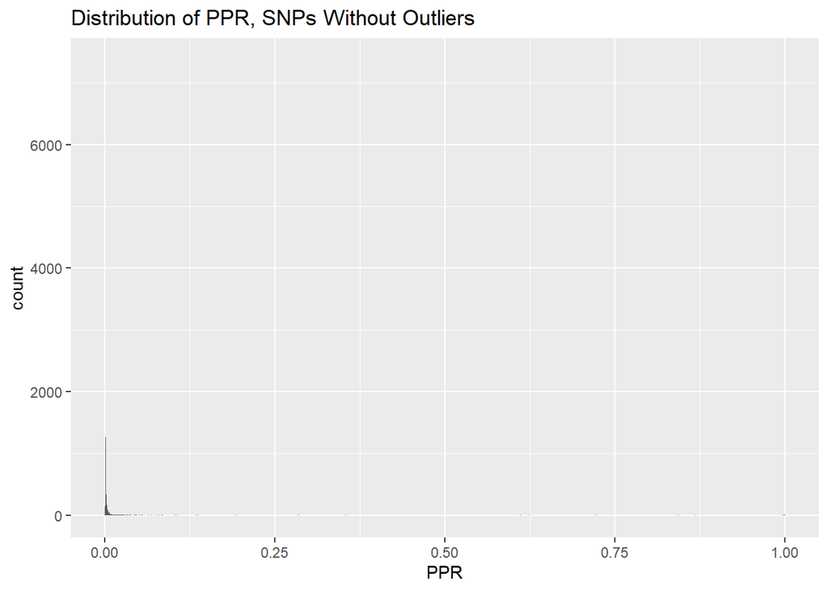

```r
ggplot(data = as.data.frame(nonout_ppr), aes(nonout_ppr)) +
  geom_histogram(binwidth = 0.0001) +
  ggtitle("Distribution of PPR, SNPs Without Outliers") +
  xlab("PPR")
```

Like before, if we ignore extreme PPR values, our histogram looks different.

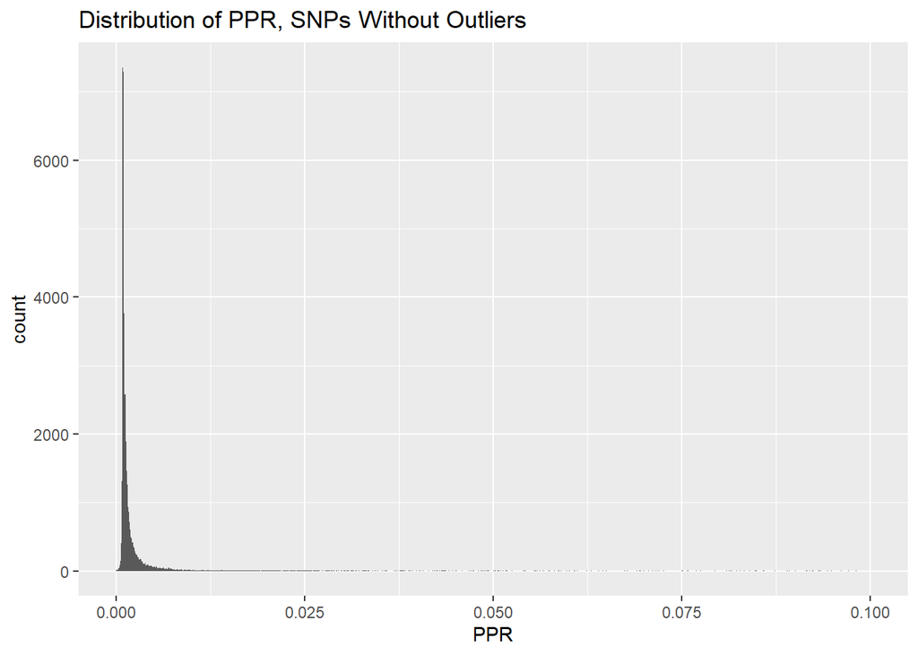

```r
ggplot(data = as.data.frame(nonout_ppr), aes(nonout_ppr)) +
  geom_histogram(binwidth = 0.0001) +
  ggtitle("Distribution of PPR, SNPs Without Outliers") +
  xlab("PPR") +
  xlim(0, 0.1)
```

In contrast, this is what the distribution of our PRP values looks like.

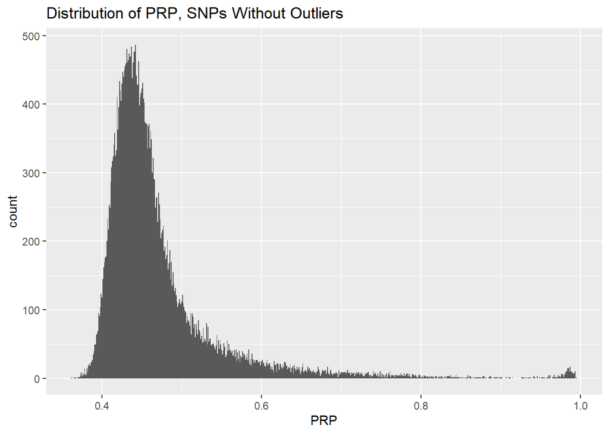

```r
ggplot(data = as.data.frame(nonout_prp), aes(nonout_prp)) +
  geom_histogram(binwidth = 0.001) +
  ggtitle("Distribution of PRP, SNPs Without Outliers") +
  xlab("PRP")
```

### Different Population Sampling

We sample from 5000 individuals. For each “study,” we sample at different allele frequencies.

```r
# allele sampling
n = 5000
allele0.01 <- rbinom(n, 2, 0.01)
allele0.1 <- rbinom(n, 2, 0.1)
allele0.25 <- rbinom(n, 2, 0.25)

# noise
epsilon <- rnorm(5000, mean = 0, sd = 1)
```

Using a linear equation, we get our phenotype values.

```r
beta = rnorm(1, mean = 0, sd = 1)
y0.01 = (beta * allele0.01) + epsilon
y0.1 = (beta * allele0.1) + epsilon
y0.25 = (beta * allele0.25) + epsilon
```

Finally we fit a linear model to get an effect size estimate.

```r
lm_model0.01 <- lm(y0.01 ~ allele0.01)
bhat0.01 <- lm_model0.01$coefficients[2]
se0.01 <- summary(lm_model0.01)$sigma

lm_model0.1 <- lm(y0.1 ~ allele0.1)
bhat0.1 <- lm_model0.1$coefficients[2]
se0.1 <- summary(lm_model0.1)$sigma

lm_model0.25 <- lm(y0.25 ~ allele0.25)
bhat0.25 <- lm_model0.25$coefficients[2]
se0.25 <- summary(lm_model0.25)$sigma
```

The effect size estimates are given in the table below. Our true effect size is `beta`.

| allele0.01 | allele0.1 | allele0.25 |
| --- | --- | --- |
| -1.074 | -0.9315 | -1.011 |

Using these predictions, we can see how MAMBA and the PRP library behave. We treat each allele frequency as its own study, and so we compare the three studies with different allele frequencies to each other.

```r
# list of our (predicted) effect size and variance
snpeffect <- c(bhat0.01, bhat0.1, bhat0.25)
snpeffect_prp <- rbind(snpeffect, snpeffect)
snpvar <- c(se0.01**2, se0.1**2, se0.25**2)
snpvar_prp <- rbind(snpvar, snpvar)
```

First we fit these results to MAMBA.

```r
diff_pop <- mamba(beta = snpeffect_prp,
                  sjk2 = snpvar_prp)
```

```r
diff_pop$outliermat
```

| snp | Oj_1 | Oj_2 | Oj_3 | ppr |
| --- | --- | --- | --- | --- |
| 1 | 0.03322111 | 0.03295981 | 0.03310119 | 0.005052808 |
| 2 | 0.03322111 | 0.03295981 | 0.03310119 | 0.005052808 |

Next we fit to the PRP model.

```r
diff_pop_prp <- posterior_prp(beta = snpeffect,
                              se = sqrt(snpvar))
diff_pop_prp$pvalue
```

```
## [1] 0.797
```

The p-value given by the PRP package is 0.797.